# The Sampling Distribution, The Posterior Distribution, and the Monte Carlo Method

## Introduction via Coin Flipping

### First Off: Frequentism

Let’s get started with the simple case of coin flipping.

Let’s start off using Monte Carlo simulation to understand the frequentist statistical logic.

```r
R <- 50000 # number of replications
N <- 1000
theta.true <- 0.6
theta.hat <- rep(0, R)

for(i in 1:R)
{
  y.raw <- rbinom(N, 1, theta.true)
  theta.hat[i] <- mean(y.raw)
}

theta.mu <- mean(theta.hat)
theta.sd <- sd(theta.hat)
curve(dnorm(x, theta.mu, theta.sd), type = "l", lwd = 3, col="blue")
hist(theta.hat, breaks=100, add=TRUE, freq=FALSE)
```

There are two main desirable properties of “good” estimators:

1. Unbiasedness: $E(\hat{\theta}) = \theta$
2. Minimum variance among all other unbiased estimators

BLUE!

### The Bootstrap

```r
N <- 5000
y.one <- rbinom(N, 1, theta.true)


R <- 50000 # number of replications
theta.hat <- rep(0, R)

for(i in 1:R)
{
  y.raw <- sample(y.one, size=2500, replace=TRUE)
  theta.hat[i] <- mean(y.raw)
}

theta.mu <- mean(theta.hat)
theta.sd <- sd(theta.hat)
curve(dnorm(x, theta.mu, theta.sd), type = "l", lwd = 3, col="red")
hist(theta.hat, breaks=100, add=TRUE, freq=FALSE)
```

### The Bayesian Approach

The Bayesian approach relied on the Bayes’ Rule:

$$p(\theta | y) \propto p(y | \theta) p(\theta)$$
A conjugate model in this case was to use:

- For the prior: $Beta(\theta | a, b)$
- For the likelihood: The $Bernoulli(y | \theta)$

We are going use an uninformative Bayesian prior. That is we will set $a = b = 1$.

```r
a.prior <- 1
b.prior <- 1
curve(dbeta(x, a.prior, a.prior), lwd = 3, type = "l", col="blue")
```

In our conjugate model, the posterior will also be $Beta(\theta | a^{\ast}, b^{\ast})$, where:

- $a^\{\ast} = N_{1} + a$ where $a$ is the prior value, and $N_{1} = $ the number of heads obtained in our sample.
- $b^{\ast} = N_{0} + b$ where $b$ is the prior value, and $N_{0} = $ the number of tails obtained in our sample.

```r
N1 <- sum(y.one)
N0 <- N - N1
a.post <- N1 + a.prior
b.post <- N0 + b.prior

curve(dbeta(x, a.post, b.post), lwd = 3, type = "l", col = "green")
hist(theta.hat, breaks=100, add=TRUE, freq=FALSE)
```

## Linear Regression

Let’s move now to the more interesting case of the workhorse of econometrics: the linear regression model.

$$y_{i} = \alpha + \beta x_{i} + u_{i}$$

```r
# This represents the DGP
N <- 10000
a <- 1.258
b <- 2.567
x <- rnorm(N)
u <- rnorm(N, 0, 5)
y <- a + b * x + u

# MN hands off the data to the econometrician
fit <- lm(y ~ x)
summary(fit)
```

Now let’s set up a Monte Carlo simulation study to estimate the sampling distribution of $\hat{\beta}$.

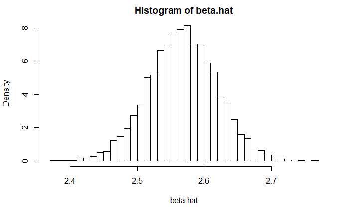

```r
R <- 10000
beta.hat <- rep(0, R)
for(i in 1:R)
{
    u <- rnorm(N, 0, 5)
    y <- a + b * x + u
    fit <- lm(y ~ x)
    beta.hat[i] <- coef(fit)[2]
}
#beta.mu <- mean(beta.hat)
#beta.sd <- mean(beta.hat)
#curve(dnorm(x, beta.mu, beta.sd), lwd = 3, type = "l", col = "blue")
hist(beta.hat, breaks = 50, freq = F)
```